# The Impact of Social Media on Mental Health

### Data Analysis using Python Project – John Bryce College

### **Source**

https://www.kaggle.com/datasets/souvikahmed071/social-media-and-mental-health/data

# **Dataset Overview**

### - This dataset contains responses from individuals about their social media usage habits and mental health indicators.

### - It’s a survey-based dataset, so each row represents one participant’s answers.

### - The dataset includes demographic information, social media behavior, and psychological self-assessments related to anxiety, depression, concentration, sleep, and self-comparison.

## This dataset is perfect for analyzing:

### - Correlation between time spent on social media and mental health indicators (anxiety, depression, sleep).

### - Differences across gender or age groups.

### - The psychological impact of social comparison and validation-seeking behaviors.

### - Behavioral patterns such as distraction, restlessness, and mindless scrolling.

## Columns Explained:

### Timestamp - The date and time when the participant submitted the survey (optional for time analysis).

### 1. What is your age? - Respondent’s age (numeric). Usually ranges from teenagers to adults in their 40s–50s.

### 2. Gender - Participant’s gender (Male / Female / Other).

### 3. Relationship Status - Indicates if the person is single, in a relationship, married, etc.

### 4. Occupation Status - Participant’s current employment status (Student, Employed, Unemployed, etc.).

### 5. What type of organizations are you affiliated with? - Whether they’re part of academic, corporate, or other institutions.

### 6. Do you use social media? - A yes/no question — confirms whether the respondent is active on social media.

### 7. What social media platforms do you commonly use? - Lists the main platforms used (Instagram, Twitter/X, TikTok, Facebook, etc.).

### 8. What is the average time you spend on social media every day? - The average daily time spent on social media, in hours. This is one of the key variables for correlation analysis.

### 9. How often do you find yourself using Social media without a specific purpose? - Measures “mindless scrolling” — higher values mean more compulsive use.

### 10. How often do you get distracted by Social media when you are busy doing something? - Indicates the level of distraction caused by social media.

### 11. Do you feel restless if you haven't used Social media in a while? - A behavioral indicator of dependency or withdrawal symptoms.

### 12. On a scale of 1 to 5, how easily distracted are you? - A self-assessment of attention span; higher = more easily distracted.

### 13. On a scale of 1 to 5, how much are you bothered by worries? - A mental health indicator measuring anxiety levels.

### 14. Do you find it difficult to concentrate on things? - Measures attention and focus difficulties, possibly linked to screen time.

### 15. On a scale of 1-5, how often do you compare yourself to other successful people through the use of social media? - A measure of social comparison — linked to self-esteem and depressive feelings.

### 16. Following the previous question, how do you feel about these comparisons, generally speaking? - Qualitative emotional response — positive, neutral, or negative.

### 17. How often do you look to seek validation from features of social media? - Measures dependence on likes/comments/feedback — often correlated with anxiety.

### 18. How often do you feel depressed or down? - Self-reported depression frequency (1 = rarely, 5 = very often). This is one of the key target variables.

### 19. On a scale of 1 to 5, how frequently does your interest in daily activities fluctuate? - Measures motivation or consistency of interest — often used in mood analysis.

### 20. On a scale of 1 to 5, how often do you face issues regarding sleep? - Indicates sleep disturbance frequency — another mental health signal.

## **Tools and Techniques**

### Python | Pandas | Matplotlib | Seaborn | Numpy | Correlation Analysis | Advanced Visualizations | Aggregationb

## **Preparation**

### Import libraries and prepare the workspace:

```python
import pandas as pd
import matplotlib.pyplot as plt
import seaborn as sb
import numpy as np


plt.style.use('seaborn-v0_8-darkgrid')
sb.set_palette('coolwarm')
```

## Loading the data and initial review:

```python
df=pd.read_csv('smmh.csv')
```

## We will check the data structure:

```python
print(df.shape)
```

```
(481, 21)
```

```python
print(df.info())
```

```
<class 'pandas.core.frame.DataFrame'>
RangeIndex: 481 entries, 0 to 480
Data columns (total 21 columns):
 #   Column                                                                                                                Non-Null Count  Dtype
---  ------                                                                                                                --------------  -----
 0   Timestamp                                                                                                             481 non-null    object
 1   1. What is your age?                                                                                                  481 non-null    float64
 2   2. Gender                                                                                                             481 non-null    object
 3   3. Relationship Status                                                                                                481 non-null    object
 4   4. Occupation Status                                                                                                  481 non-null    object
 5   5. What type of organizations are you affiliated with?                                                                451 non-null    object
 6   6. Do you use social media?                                                                                           481 non-null    object
 7   7. What social media platforms do you commonly use?                                                                   481 non-null    object
 8   8. What is the average time you spend on social media every day?                                                      481 non-null    object
 9   9. How often do you find yourself using Social media without a specific purpose?                                      481 non-null    int64
 10  10. How often do you get distracted by Social media when you are busy doing something?                                481 non-null    int64
 11  11. Do you feel restless if you haven't used Social media in a while?                                                 481 non-null    int64
 12  12. On a scale of 1 to 5, how easily distracted are you?                                                              481 non-null    int64
 13  13. On a scale of 1 to 5, how much are you bothered by worries?                                                       481 non-null    int64
 14  14. Do you find it difficult to concentrate on things?                                                                481 non-null    int64
 15  15. On a scale of 1-5, how often do you compare yourself to other successful people through the use of social media?  481 non-null    int64
 16  16. Following the previous question, how do you feel about these comparisons, generally speaking?                     481 non-null    int64
 17  17. How often do you look to seek validation from features of social media?                                           481 non-null    int64
 18  18. How often do you feel depressed or down?                                                                          481 non-null    int64
 19  19. On a scale of 1 to 5, how frequently does your interest in daily activities fluctuate?                            481 non-null    int64
 20  20. On a scale of 1 to 5, how often do you face issues regarding sleep?                                               481 non-null    int64
dtypes: float64(1), int64(12), object(8)
memory usage: 79.0+ KB
None
```

## Data Characteristics:

### Key quantitative variables:

### Average time on social media (Q8)

### Anxiety level (Q13)

### Depression frequency (Q18)

### Sleep issues (Q20)

### Key categorical variables:

### Gender (Q2), Age (Q1), Occupation (Q4)

```python
df.head()
```

|  | Timestamp | 1. What is your age? | 2. Gender | 3. Relationship Status | 4. Occupation Status | 5. What type of organizations are you affiliated with? | 6. Do you use social media? | 7. What social media platforms do you commonly use? | 8. What is the average time you spend on social media every day? | 9. How often do you find yourself using Social media without a specific purpose? | ... | 11. Do you feel restless if you haven't used Social media in a while? | 12. On a scale of 1 to 5, how easily distracted are you? | 13. On a scale of 1 to 5, how much are you bothered by worries? | 14. Do you find it difficult to concentrate on things? | 15. On a scale of 1-5, how often do you compare yourself to other successful people through the use of social media? | 16. Following the previous question, how do you feel about these comparisons, generally speaking? | 17. How often do you look to seek validation from features of social media? | 18. How often do you feel depressed or down? | 19. On a scale of 1 to 5, how frequently does your interest in daily activities fluctuate? | 20. On a scale of 1 to 5, how often do you face issues regarding sleep? |
| --- | --- | --- | --- | --- | --- | --- | --- | --- | --- | --- | --- | --- | --- | --- | --- | --- | --- | --- | --- | --- | --- |
| 0 | 4/18/2022 19:18:47 | 21.0 | Male | In a relationship | University Student | University | Yes | Facebook, Twitter, Instagram, YouTube, Discord... | Between 2 and 3 hours | 5 | ... | 2 | 5 | 2 | 5 | 2 | 3 | 2 | 5 | 4 | 5 |
| 1 | 4/18/2022 19:19:28 | 21.0 | Female | Single | University Student | University | Yes | Facebook, Twitter, Instagram, YouTube, Discord... | More than 5 hours | 4 | ... | 2 | 4 | 5 | 4 | 5 | 1 | 1 | 5 | 4 | 5 |
| 2 | 4/18/2022 19:25:59 | 21.0 | Female | Single | University Student | University | Yes | Facebook, Instagram, YouTube, Pinterest | Between 3 and 4 hours | 3 | ... | 1 | 2 | 5 | 4 | 3 | 3 | 1 | 4 | 2 | 5 |
| 3 | 4/18/2022 19:29:43 | 21.0 | Female | Single | University Student | University | Yes | Facebook, Instagram | More than 5 hours | 4 | ... | 1 | 3 | 5 | 3 | 5 | 1 | 2 | 4 | 3 | 2 |
| 4 | 4/18/2022 19:33:31 | 21.0 | Female | Single | University Student | University | Yes | Facebook, Instagram, YouTube | Between 2 and 3 hours | 3 | ... | 4 | 4 | 5 | 5 | 3 | 3 | 3 | 4 | 4 | 1 |

5 rows × 21 columns

## Explanation:

### We're checking how many rows and columns there are, what types of data exist and whether there are any missing values.

## **In this step, we examine the dataset for missing data and detect potential outliers:**

### Checking for missing values:

```python
missing_values = df.isnull().sum()
print("Missing Values per Column:\n", missing_values)
```

```
Missing Values per Column:
 Timestamp                                                                                                                0
1. What is your age?                                                                                                     0
2. Gender                                                                                                                0
3. Relationship Status                                                                                                   0
4. Occupation Status                                                                                                     0
5. What type of organizations are you affiliated with?                                                                  30
6. Do you use social media?                                                                                              0
7. What social media platforms do you commonly use?                                                                      0
8. What is the average time you spend on social media every day?                                                         0
9. How often do you find yourself using Social media without a specific purpose?                                         0
10. How often do you get distracted by Social media when you are busy doing something?                                   0
11. Do you feel restless if you haven't used Social media in a while?                                                    0
12. On a scale of 1 to 5, how easily distracted are you?                                                                 0
13. On a scale of 1 to 5, how much are you bothered by worries?                                                          0
14. Do you find it difficult to concentrate on things?                                                                   0
15. On a scale of 1-5, how often do you compare yourself to other successful people through the use of social media?     0
16. Following the previous question, how do you feel about these comparisons, generally speaking?                        0
17. How often do you look to seek validation from features of social media?                                              0
18. How often do you feel depressed or down?                                                                             0
19. On a scale of 1 to 5, how frequently does your interest in daily activities fluctuate?                               0
20. On a scale of 1 to 5, how often do you face issues regarding sleep?                                                  0
dtype: int64
```

### Identify numeric columns:

```python
numeric_cols = df.select_dtypes(include=['int64', 'float64']).columns
```

### Detect outliers using the IQR method:

```python
outlier_summary = {}
for col in numeric_cols:
    Q1 = df[col].quantile(0.25)
    Q3 = df[col].quantile(0.75)
    IQR = Q3 - Q1
    lower = Q1 - 1.5 * IQR
    upper = Q3 + 1.5 * IQR
    outliers = ((df[col] < lower) | (df[col] > upper)).sum()
    outlier_summary[col] = outliers

print("\nOutliers per Numeric Column:\n", outlier_summary)
```

[output not shown]

## Results:

### The column “5. What type of organizations are you affiliated with?” contains 30 missing values.

### All other columns have no missing data.

## Outliers detected:

### 1. What is your age? 84

### 9. How often do you find yourself using Social media without a specific purpose? 20

### 11. Do you feel restless if you haven't used Social media in a while? 44

### 12. On a scale of 1 to 5, how easily distracted are you? 33

### 16. Following the previous question, how do you feel about these comparisons, generally speaking? 33

## Replacing 'Null' values:

```python
df.fillna({"5. What type of organizations are you affiliated with?": "Unknown"}, inplace=True)
```

## Removing unrealistic ages:

```python
df = df[(df["1. What is your age?"] >= 15) & (df["1. What is your age?"] <= 60)]
```

## Explanation:

### The missing data in the “organization” column likely results from participants who are not affiliated with any institution.

### The age column shows some unrealistic values.

### Other outliers in 1–5 scale questions are probably valid extreme responses, not actual errors.

## Summary:

### The dataset is now clean, consistent, and ready for further statistical analysis and visualization.

## **Data Transformation**

### In this stage, we transform specific columns to ensure data consistency and correct data types for analysis.

## Convert 'Timestamp' column to datetime format:

```python
df["Timestamp"] = pd.to_datetime(df["Timestamp"], errors="coerce")
```

## Rename columns for easier reference:

```python
df.rename(columns={
    "1. What is your age?": "Age",
    "2. Gender": "Gender",
    "3. Relationship Status": "Relationship_Status",
    "4. Occupation Status": "Occupation_Status",
    "5. What type of organizations are you affiliated with?": "Organization_Type",
    "6. Do you use social media?": "Uses_Social_Media",
    "7. What social media platforms do you commonly use?": "Platforms_Used",
    "8. What is the average time you spend on social media every day?": "Time_on_Social_Media",
    "9. How often do you find yourself using Social media without a specific purpose?": "Usage_Without_Purpose",
    "10. How often do you get distracted by Social media when you are busy doing something?": "Distraction_Level",
    "11. Do you feel restless if you haven't used Social media in a while?": "Restlessness_Without_SM",
    "12. On a scale of 1 to 5, how easily distracted are you?": "Easily_Distracted",
    "13. On a scale of 1 to 5, how much are you bothered by worries?": "Worry_Level",
    "14. Do you find it difficult to concentrate on things?": "Difficulty_Concentrating",
    "15. On a scale of 1-5, how often do you compare yourself to other successful people through the use of social media?": "Comparison_Frequency",
    "16. Following the previous question, how do you feel about these comparisons, generally speaking?": "Feeling_After_Comparison",
    "17. How often do you look to seek validation from features of social media?": "Validation_Seeking",
    "18. How often do you feel depressed or down?": "Depression_Level",
    "19. On a scale of 1 to 5, how frequently does your interest in daily activities fluctuate?": "Interest_Fluctuation",
    "20. On a scale of 1 to 5, how often do you face issues regarding sleep?": "Sleep_Issues"
}, inplace=True)
```

## Verify numeric columns are indeed numeric:

```python
numeric_cols = df.select_dtypes(include=['int64', 'float64']).columns
print("Numeric Columns:\n", numeric_cols)
```

[output not shown]

```python
df.dtypes
```

```
Timestamp                   datetime64[ns]
Age                                float64
Gender                              object
Relationship_Status                 object
Occupation_Status                   object
Organization_Type                   object
Uses_Social_Media                   object
Platforms_Used                      object
Time_on_Social_Media                object
Usage_Without_Purpose                int64
Distraction_Level                    int64
Restlessness_Without_SM              int64
Easily_Distracted                    int64
Worry_Level                          int64
Difficulty_Concentrating             int64
Comparison_Frequency                 int64
Feeling_After_Comparison             int64
Validation_Seeking                   int64
Depression_Level                     int64
Interest_Fluctuation                 int64
Sleep_Issues                         int64
dtype: object
```

## Time Transformation:

### To simplify analysis and ensure consistent categories, these responses were normalized into standardized time ranges:

```python
def normalize_time(value):
    if isinstance(value, str):
        if "Less than 1" in value:
            return "<1h"
        elif "1 and 2" in value:
            return "1–2h"
        elif "2 and 3" in value:
            return "2–3h"
        elif "3 and 4" in value:
            return "3–4h"
        elif "4 and 5" in value:
            return "4–5h"
        elif "More than 5" in value:
            return ">5h"
    return "Other"
df["Time_on_Social_Media"] = df["Time_on_Social_Media"].apply(normalize_time)
```

## Text-based columns Transformation into category data type:

### This transformation improves performance during grouping and visualization,

### and ensures that non-numeric data is properly recognized as categorical information.

```python
categorical_cols = ["Gender","Relationship_Status","Occupation_Status","Organization_Type","Uses_Social_Media","Time_on_Social_Media","Platforms_Used"                     ]
for col in categorical_cols:df[col] = df[col].astype("category")
```

```python
df[categorical_cols].dtypes
```

```
Gender                  category
Relationship_Status     category
Occupation_Status       category
Organization_Type       category
Uses_Social_Media       category
Time_on_Social_Media    category
Platforms_Used          category
dtype: object
```

## **Descriptive Statistics**

### In this stage, descriptive statistics were calculated to summarize the dataset and better understand

### general trends across numeric variables such as age, distraction levels, worries, and emotional indicators.

```python
numeric_summary = df.describe().T
```

```python
numeric_summary[["mean", "50%", "std", "min", "max"]].rename(columns={"50%": "median"})
```

|  | mean | median | std | min | max |
| --- | --- | --- | --- | --- | --- |
| Timestamp | 2022-05-01 19:50:03.095339008 | 2022-04-26 23:44:41.500000 | NaN | 2022-04-18 19:18:47 | 2022-11-12 13:16:50 |
| Age | 25.984534 | 22.0 | 9.063163 | 15.0 | 60.0 |
| Usage_Without_Purpose | 3.54661 | 4.0 | 1.097163 | 1.0 | 5.0 |
| Distraction_Level | 3.307203 | 3.0 | 1.33104 | 1.0 | 5.0 |
| Restlessness_Without_SM | 2.588983 | 3.0 | 1.258738 | 1.0 | 5.0 |
| Easily_Distracted | 3.347458 | 3.0 | 1.179277 | 1.0 | 5.0 |
| Worry_Level | 3.561441 | 4.0 | 1.283753 | 1.0 | 5.0 |
| Difficulty_Concentrating | 3.252119 | 3.0 | 1.344169 | 1.0 | 5.0 |
| Comparison_Frequency | 2.832627 | 3.0 | 1.405009 | 1.0 | 5.0 |
| Feeling_After_Comparison | 2.769068 | 3.0 | 1.054591 | 1.0 | 5.0 |
| Validation_Seeking | 2.451271 | 2.0 | 1.240573 | 1.0 | 5.0 |
| Depression_Level | 3.260593 | 3.0 | 1.308917 | 1.0 | 5.0 |
| Interest_Fluctuation | 3.161017 | 3.0 | 1.261687 | 1.0 | 5.0 |
| Sleep_Issues | 3.192797 | 3.0 | 1.459616 | 1.0 | 5.0 |

## Explanation:

### -The average respondent age is around 26, with most participants in their early twenties.

### -The mean distraction level (3.3) and worry level (3.5) indicate a moderate emotional load.

### -Depression and sleep issue scores hover around 3, suggesting mild to moderate mental strain.

### -Lower averages in validation seeking (2.4) show that most respondents do not heavily rely on external approval from social media.

## Identifying Extreme Values (Minimum and Maximum):

### In this step, the minimum and maximum values for each numeric column were identified.

```python
extreme_values = df.describe().T[["min", "max"]]
extreme_values
```

|  | min | max |
| --- | --- | --- |
| Timestamp | 2022-04-18 19:18:47 | 2022-11-12 13:16:50 |
| Age | 15.0 | 60.0 |
| Usage_Without_Purpose | 1.0 | 5.0 |
| Distraction_Level | 1.0 | 5.0 |
| Restlessness_Without_SM | 1.0 | 5.0 |
| Easily_Distracted | 1.0 | 5.0 |
| Worry_Level | 1.0 | 5.0 |
| Difficulty_Concentrating | 1.0 | 5.0 |
| Comparison_Frequency | 1.0 | 5.0 |
| Feeling_After_Comparison | 1.0 | 5.0 |
| Validation_Seeking | 1.0 | 5.0 |
| Depression_Level | 1.0 | 5.0 |
| Interest_Fluctuation | 1.0 | 5.0 |
| Sleep_Issues | 1.0 | 5.0 |

## **Analysis by Categories**

### In this stage, comparisons were made between different demographic and behavioral groups to explore potential trends and differences:

## Simplify gender categories

### keep only 'Male' and 'Female', others become 'Other'

```python
df["Gender"] = df["Gender"].apply(lambda x: x if x in ["Male", "Female"] else "Other")
```

## Gender Differences:

```python
gender_comparison = df.groupby("Gender")[[
"Worry_Level", "Depression_Level", "Sleep_Issues",
"Distraction_Level", "Validation_Seeking"
]].mean().round(2)

gender_comparison
```

| Gender | Worry_Level | Depression_Level | Sleep_Issues | Distraction_Level | Validation_Seeking |
| --- | --- | --- | --- | --- | --- |
| Female | 3.68 | 3.38 | 3.16 | 3.41 | 2.49 |
| Male | 3.40 | 3.10 | 3.26 | 3.18 | 2.40 |
| Other | 3.67 | 3.50 | 2.17 | 3.17 | 2.33 |

## Explanation:

### -Females report slightly higher levels of worry and depression compared to males.

### -Males show a similar or slightly higher average in sleep issues, suggesting fatigue may affect both genders equally.

### -Both genders display moderate levels of distraction and validation seeking (2.4–3.4 range).

### -Other gender entries (e.g., Non-binary, Trans) are rare outliers and should not be used for generalization due to very small sample size.

## Time Spent on Social Media:

```python
time_comparison = df.groupby("Time_on_Social_Media")[[
"Depression_Level", "Worry_Level", "Sleep_Issues"
]].mean().round(2)

time_comparison
```

| Time_on_Social_Media | Depression_Level | Worry_Level | Sleep_Issues |
| --- | --- | --- | --- |
| 1–2h | 2.78 | 3.03 | 2.86 |
| 2–3h | 3.17 | 3.39 | 3.12 |
| 3–4h | 3.39 | 3.92 | 3.29 |
| 4–5h | 3.49 | 3.72 | 3.43 |
| >5h | 3.77 | 4.01 | 3.43 |
| Other | 2.00 | 2.35 | 2.56 |

## Explanation:

### -There’s a clear upward trend — as daily time on social media increases, so do depression, worry, and sleep issues.

### -Participants spending more than 5 hours/day show the highest averages across all mental health indicators.

### -This supports the hypothesis that excessive social media use correlates with poorer mental well-being.

## Compare emotional indicators by relationship status:

```python
relationship_comparison = df.groupby("Relationship_Status")[[
"Depression_Level", "Worry_Level", "Sleep_Issues", "Validation_Seeking"
]].mean().round(2)

relationship_comparison
```

| Relationship_Status | Depression_Level | Worry_Level | Sleep_Issues | Validation_Seeking |
| --- | --- | --- | --- | --- |
| Divorced | 2.67 | 3.00 | 2.67 | 3.50 |
| In a relationship | 3.45 | 3.68 | 3.22 | 2.67 |
| Married | 2.45 | 2.86 | 2.64 | 2.22 |
| Single | 3.50 | 3.79 | 3.40 | 2.44 |

### Explanation:

### -Singles show the highest levels of depression, worry, and sleep problems.

### -Married participants report the lowest scores across all indicators — suggesting more emotional stability.

### -Divorced individuals show high validation seeking, possibly reflecting emotional vulnerability or social comparison tendencies.

## Compare mental indicators by occupation status:

```python
occupation_comparison = df.groupby("Occupation_Status")[[
"Depression_Level", "Worry_Level", "Sleep_Issues"
]].mean().round(2)

occupation_comparison
```

| Occupation_Status | Depression_Level | Worry_Level | Sleep_Issues |
| --- | --- | --- | --- |
| Retired | 3.14 | 2.86 | 3.00 |
| Salaried Worker | 2.63 | 3.04 | 2.71 |
| School Student | 3.28 | 3.74 | 3.12 |
| University Student | 3.54 | 3.79 | 3.43 |

### Explanation:

### -University students display the highest averages in depression, worry, and sleep issues,

### possibly due to academic pressure and heavy social media use.

### -Working adults report the lowest emotional strain, likely due to more structured routines.

### -Students in general seem to be the group most emotionally affected by social media.

## **Data Aggregation by Different Dimensions**

### In this step, the dataset was aggregated across different dimensions to summarize patterns

### and identify trends over time and demographic factors.

## Correlation between emotional and behavioral indicators:

```python
corr = df[[
"Depression_Level", "Worry_Level", "Sleep_Issues",
"Distraction_Level", "Validation_Seeking"
]].corr().round(2)
corr
```

|  | Depression_Level | Worry_Level | Sleep_Issues | Distraction_Level | Validation_Seeking |
| --- | --- | --- | --- | --- | --- |
| Depression_Level | 1.00 | 0.58 | 0.37 | 0.39 | 0.26 |
| Worry_Level | 0.58 | 1.00 | 0.32 | 0.35 | 0.20 |
| Sleep_Issues | 0.37 | 0.32 | 1.00 | 0.25 | 0.12 |
| Distraction_Level | 0.39 | 0.35 | 0.25 | 1.00 | 0.27 |
| Validation_Seeking | 0.26 | 0.20 | 0.12 | 0.27 | 1.00 |

## Explanation:

### -This correlation matrix shows how different emotional and behavioral variables relate to each other.

### -Positive correlations (close to +1) indicate that as one variable increases, the other tends to increase as well.

### -Negative correlations (close to -1) indicate an inverse relationship.

## Aggregation by time spent on social media with multiple metrics:

```python
agg_time = df.groupby("Time_on_Social_Media")[[
"Depression_Level", "Worry_Level", "Sleep_Issues"
]].agg(["mean", "median", "std", "count"]).round(2)

agg_time
```

| Time_on_Social_Media | Depression_Level mean | Depression_Level median | Depression_Level std | Depression_Level count | Worry_Level mean | Worry_Level median | Worry_Level std | Worry_Level count | Sleep_Issues mean | Sleep_Issues median | Sleep_Issues std | Sleep_Issues count |
| --- | --- | --- | --- | --- | --- | --- | --- | --- | --- | --- | --- | --- |
| 1–2h | 2.78 | 3.0 | 1.32 | 69 | 3.03 | 3.0 | 1.33 | 69 | 2.86 | 3.0 | 1.51 | 69 |
| 2–3h | 3.17 | 3.0 | 1.31 | 99 | 3.39 | 3.0 | 1.27 | 99 | 3.12 | 3.0 | 1.37 | 99 |
| 3–4h | 3.39 | 3.0 | 1.23 | 92 | 3.92 | 4.0 | 1.11 | 92 | 3.29 | 3.0 | 1.39 | 92 |
| 4–5h | 3.49 | 4.0 | 1.16 | 65 | 3.72 | 4.0 | 1.11 | 65 | 3.43 | 4.0 | 1.42 | 65 |
| >5h | 3.77 | 4.0 | 1.15 | 113 | 4.01 | 4.0 | 1.12 | 113 | 3.43 | 4.0 | 1.48 | 113 |
| Other | 2.00 | 2.0 | 1.15 | 34 | 2.35 | 2.0 | 1.32 | 34 | 2.56 | 2.0 | 1.56 | 34 |

## Create age groups:

```python
df["Age_Group"] = pd.cut(df["Age"], bins=[15, 20, 25, 30, 40, 60])
```

## Aggregation by age group with multiple metrics:

```python
agg_age = df.groupby("Age_Group")[[
"Depression_Level", "Worry_Level", "Sleep_Issues"
]].agg(["mean", "median", "min", "max"]).round(2)

agg_age
```

| Age_Group | Depression_Level mean | Depression_Level median | Depression_Level min | Depression_Level max | Worry_Level mean | Worry_Level median | Worry_Level min | Worry_Level max | Sleep_Issues mean | Sleep_Issues median | Sleep_Issues min | Sleep_Issues max |
| --- | --- | --- | --- | --- | --- | --- | --- | --- | --- | --- | --- | --- |
| (15, 20] | 3.44 | 4.0 | 1 | 5 | 3.93 | 4.0 | 1 | 5 | 3.44 | 4.0 | 1 | 5 |
| (20, 25] | 3.52 | 4.0 | 1 | 5 | 3.71 | 4.0 | 1 | 5 | 3.32 | 4.0 | 1 | 5 |
| (25, 30] | 3.60 | 4.0 | 1 | 5 | 3.83 | 4.0 | 1 | 5 | 3.28 | 4.0 | 1 | 5 |
| (30, 40] | 2.42 | 2.0 | 1 | 5 | 2.76 | 3.0 | 1 | 5 | 2.61 | 2.0 | 1 | 5 |
| (40, 60] | 1.98 | 2.0 | 1 | 4 | 2.47 | 2.0 | 1 | 5 | 2.47 | 2.0 | 1 | 5 |

## Explanation:

### suggesting greater emotional stability with age.

## Perform aggregation by Gender and Age Groups:

```python
agg_gender_age = df.groupby(["Gender", "Age_Group"])[[
"Depression_Level", "Worry_Level", "Sleep_Issues"
]].agg(["mean", "median", "std", "count"]).round(2)

agg_gender_age
```

| Gender | Age_Group | Depression_Level mean | Depression_Level median | Depression_Level std | Depression_Level count | Worry_Level mean | Worry_Level median | Worry_Level std | Worry_Level count | Sleep_Issues mean | Sleep_Issues median | Sleep_Issues std | Sleep_Issues count |
| --- | --- | --- | --- | --- | --- | --- | --- | --- | --- | --- | --- | --- | --- |
| Female | (15, 20] | 3.58 | 4.0 | 1.24 | 52 | 4.12 | 4.0 | 1.08 | 52 | 3.50 | 4.0 | 1.50 | 52 |
|  | (20, 25] | 3.57 | 4.0 | 1.17 | 143 | 3.76 | 4.0 | 1.17 | 143 | 3.22 | 3.0 | 1.43 | 143 |
|  | (25, 30] | 3.58 | 4.0 | 1.18 | 31 | 3.87 | 4.0 | 1.02 | 31 | 3.16 | 4.0 | 1.39 | 31 |
|  | (30, 40] | 2.26 | 2.0 | 1.37 | 19 | 2.42 | 2.0 | 1.35 | 19 | 2.58 | 2.0 | 1.57 | 19 |
|  | (40, 60] | 1.80 | 2.0 | 0.86 | 15 | 2.53 | 2.0 | 1.06 | 15 | 2.13 | 2.0 | 1.25 | 15 |
| Male | (15, 20] | 3.24 | 3.0 | 1.44 | 34 | 3.68 | 4.0 | 1.25 | 34 | 3.29 | 3.5 | 1.45 | 34 |
|  | (20, 25] | 3.45 | 3.0 | 1.18 | 102 | 3.65 | 4.0 | 1.26 | 102 | 3.56 | 4.0 | 1.35 | 102 |
|  | (25, 30] | 3.62 | 3.5 | 1.31 | 16 | 3.75 | 4.0 | 1.34 | 16 | 3.50 | 3.5 | 1.41 | 16 |
|  | (30, 40] | 2.64 | 2.0 | 1.28 | 14 | 3.21 | 3.0 | 0.97 | 14 | 2.64 | 2.0 | 1.60 | 14 |
|  | (40, 60] | 2.05 | 2.0 | 0.96 | 38 | 2.45 | 2.0 | 1.25 | 38 | 2.61 | 2.0 | 1.31 | 38 |
| Other | (15, 20] | 3.50 | 3.5 | 0.71 | 2 | 3.50 | 3.5 | 2.12 | 2 | 4.50 | 4.5 | 0.71 | 2 |
|  | (20, 25] | 3.50 | 4.0 | 1.73 | 4 | 3.75 | 4.5 | 1.89 | 4 | 1.00 | 1.0 | 0.00 | 4 |
|  | (25, 30] | NaN | NaN | NaN | 0 | NaN | NaN | NaN | 0 | NaN | NaN | NaN | 0 |
|  | (30, 40] | NaN | NaN | NaN | 0 | NaN | NaN | NaN | 0 | NaN | NaN | NaN | 0 |
|  | (40, 60] | NaN | NaN | NaN | 0 | NaN | NaN | NaN | 0 | NaN | NaN | NaN | 0 |

## Explanation:

### -The gender column was simplified so that all rare or unclear gender responses (e.g., Non-binary, Trans, unsure)

### were merged under a single category called "Other".

### -The aggregation groups participants by both Gender and Age_Group, calculating mean, median, std, and count for each combination.

### -Females (15–25) may show higher average depression and worry than males in the same age range.

### -For older participants (40+), both genders show similar levels, suggesting emotional stability increases with age.

## **Trend Analysis Over Time**

## Extract month and year for trend analysis

```python
df["Year"] = df["Timestamp"].dt.year
df["Month"] = df["Timestamp"].dt.month
```

## Monthly Trend of Mental Health Indicators:

```python
monthly_trend = df.groupby(["Year", "Month"])[[
"Depression_Level", "Worry_Level", "Sleep_Issues"
]].mean().round(2)

monthly_trend
```

| Year | Month | Depression_Level | Worry_Level | Sleep_Issues |
| --- | --- | --- | --- | --- |
| 2022 | 4 | 3.08 | 3.35 | 3.03 |
|  | 5 | 3.45 | 3.79 | 3.36 |
|  | 7 | 4.00 | 3.00 | 4.00 |
|  | 11 | 2.00 | 1.00 | 3.00 |

## Explanation:

### -This aggregation groups all responses by months and year (there were responses only in 2022) and calculates the average levels of depression,

### worry, and sleep issues for each period.

### -It allows us to detect if there were any noticeable changes in emotional well-being over time.

### -If depression and worry scores increase over consecutive months,

### this may suggest rising emotional stress or heavier social media usage during that period.

## Create a quarter column:

```python
df["Quarter"] = df["Timestamp"].dt.to_period("Q")
```

## Average mental health indicators by quarter:

```python
quarterly_trend = df.groupby("Quarter")[[
"Depression_Level", "Worry_Level", "Sleep_Issues"
]].mean().round(2)

quarterly_trend
```

| Quarter | Depression_Level | Worry_Level | Sleep_Issues |
| --- | --- | --- | --- |
| 2022Q2 | 3.26 | 3.57 | 3.19 |
| 2022Q3 | 4.00 | 3.00 | 4.00 |
| 2022Q4 | 2.00 | 1.00 | 3.00 |

## **Data Visualization**

### All visualizations below were created using Matplotlib and Seaborn.

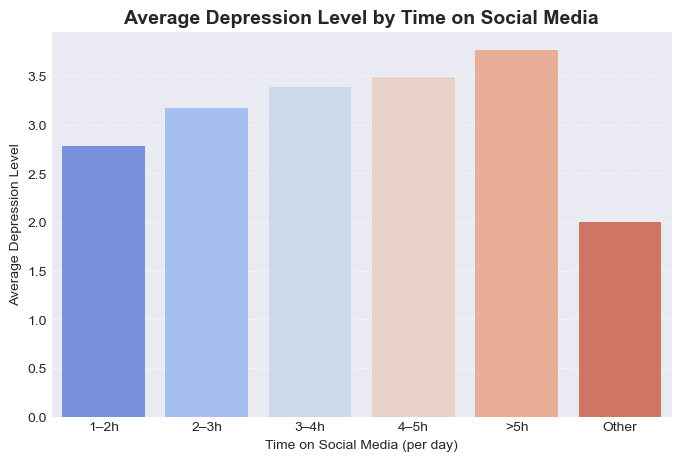

```python
plt.figure(figsize=(8,5))
sb.barplot(data=df, x="Time_on_Social_Media", y="Depression_Level", errorbar=None, palette="coolwarm")
plt.title("Average Depression Level by Time on Social Media", fontsize=14, weight="bold")
plt.xlabel("Time on Social Media (per day)")
plt.ylabel("Average Depression Level")
plt.grid(axis='y', linestyle='--', alpha=0.6)
plt.show()
```

## Explanation:

### Depression levels clearly increase with longer social media use —

### participants spending more than 5 hours a day report the highest scores.

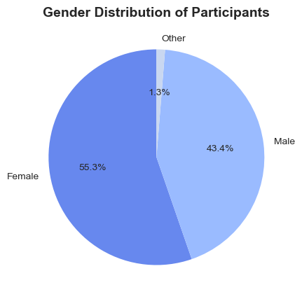

```python
gender_counts=df["Gender"].value_counts()
plt.figure(figsize=(5,5))
plt.pie(gender_counts, labels=gender_counts.index, autopct='%1.1f%%', startangle=90, colors=sb.color_palette("coolwarm"))
plt.title("Gender Distribution of Participants", fontsize=14, weight="bold")
plt.show()
```

## Explanation:

### This chart shows the demographic composition of the dataset —

### most respondents identify as male or female, with a small portion as “Other”.

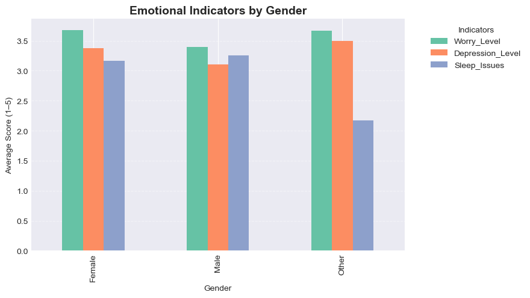

```python
plt.figure(figsize=(8,5))
gender_means = df.groupby("Gender")[["Worry_Level", "Depression_Level", "Sleep_Issues"]].mean().round(2)
gender_means.plot(kind="bar", figsize=(8,5), color=["#66c2a5","#fc8d62","#8da0cb"])
plt.title("Emotional Indicators by Gender", fontsize=14, weight="bold")
plt.xlabel("Gender")
plt.ylabel("Average Score (1–5)")
plt.grid(axis='y', linestyle='--', alpha=0.5)
plt.legend(title="Indicators", bbox_to_anchor=(1.05, 1), loc='upper left')
plt.show()
```

## Explanation:

### Females show slightly higher averages in worry and depression, while sleep issues are similar across genders.

```python
df["Mental_Health_Index"] = df[[
"Depression_Level", "Worry_Level", "Sleep_Issues"
]].mean(axis=1).round(2)
```

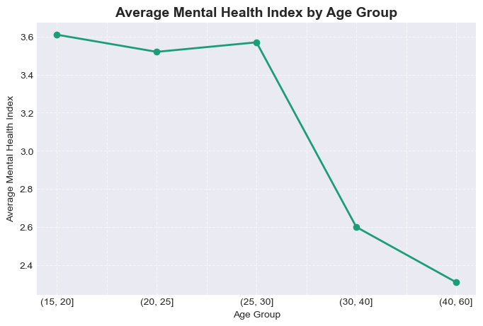

```python
df["Age_Group"] = pd.cut(df["Age"], bins=[15,20,25,30,40,60,80])
age_index = df.groupby("Age_Group")["Mental_Health_Index"].mean().round(2)
plt.figure(figsize=(8,5))
age_index.plot(kind="line", marker="o", color="#1b9e77", linewidth=2)
plt.title("Average Mental Health Index by Age Group", fontsize=14, weight="bold")
plt.xlabel("Age Group")
plt.ylabel("Average Mental Health Index")
plt.grid(True, linestyle='--', alpha=0.6)
plt.show()
```

## Explanation:

### Mental health strain is higher among younger participants (15–25), while older groups (40+) show greater emotional stability.

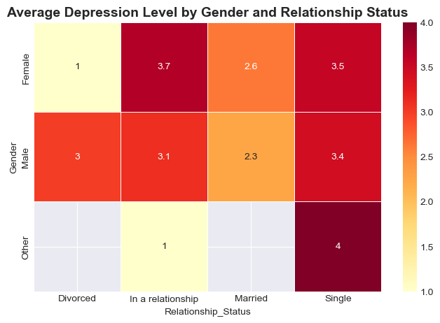

```python
plt.figure(figsize=(8,5))
pivot = df.pivot_table(values="Depression_Level", index="Gender", columns="Relationship_Status", aggfunc="mean")
sb.heatmap(pivot, annot=True, cmap="YlOrRd", linewidths=0.5)
plt.title("Average Depression Level by Gender and Relationship Status", fontsize=14, weight="bold")
plt.show()
```

## Explanation:

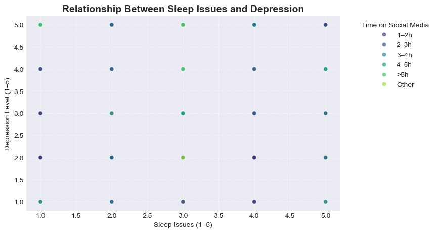

```python
plt.figure(figsize=(8,5))
sb.scatterplot(data=df, x="Sleep_Issues", y="Depression_Level", hue="Time_on_Social_Media", palette="viridis", alpha=0.7)
plt.title("Relationship Between Sleep Issues and Depression", fontsize=14, weight="bold")
plt.xlabel("Sleep Issues (1–5)")
plt.ylabel("Depression Level (1–5)")
plt.legend(title="Time on Social Media",bbox_to_anchor=(1.05, 1), loc='upper left')
plt.grid(True, linestyle='--', alpha=0.5)
plt.show()
```

## Explanation:

### As sleep issues increase, so does depression level.

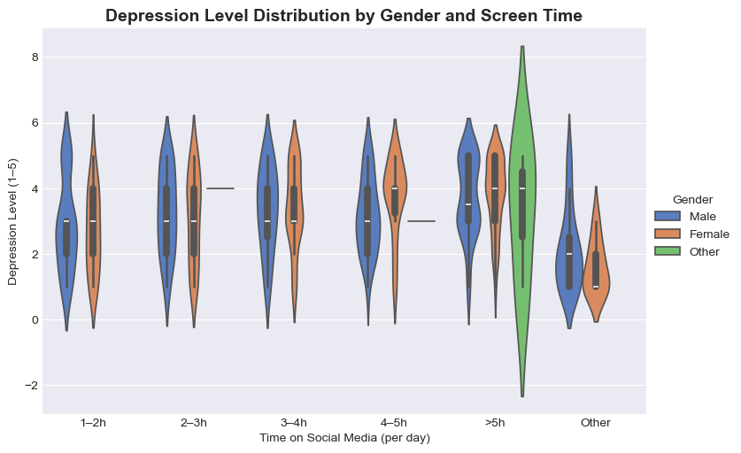

```python
plt.figure(figsize=(10,6))
sb.catplot(data=df, x="Time_on_Social_Media", y="Depression_Level", hue="Gender", kind="violin",
palette="muted", height=5, aspect=1.5)
plt.title("Depression Level Distribution by Gender and Screen Time", fontsize=14, weight="bold")
plt.xlabel("Time on Social Media (per day)")
plt.ylabel("Depression Level (1–5)")
plt.show()
```

## Explanation:

### The violin plot shows that depression levels tend to be higher and more varied among females as daily screen time increases.

### Male participants generally cluster in lower depression ranges,

### while females spending more than 4–5 hours/day show a wider, higher distribution of scores.

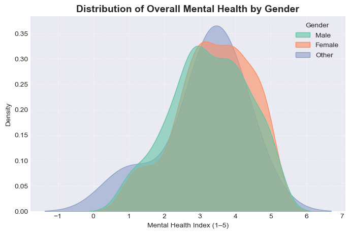

```python
plt.figure(figsize=(8,5))
sb.kdeplot(data=df, x="Mental_Health_Index", hue="Gender", fill=True, common_norm=False, palette="Set2", alpha=0.6)
plt.title("Distribution of Overall Mental Health by Gender", fontsize=14, weight="bold")
plt.xlabel("Mental Health Index (1–5)")
plt.ylabel("Density")
plt.grid(True, linestyle='--', alpha=0.4)
plt.show()
```

## **Insights & Recommendations**

### -Encourage balanced digital habits and screen-time awareness.

### -Focus mental wellness programs on young heavy users, especially females.

### -Future research should explore long-term effects and platform-specific impacts.

## **Final Note**

### Social media connects — but also drains.

### Balance, awareness, and mindful usage are key to staying emotionally healthy online.